# Wine Case

1. Evaluation of the average causal effect: For this section, we first look at the average effect of open, click and purch. Then plot a bar chart to see the results.

```r
rm(list = ls())
library(dplyr)
library(tidyr)
library(data.table)
```

```r
library(ggplot2)
library(grf)
wine <- read.csv('test_data_1904.csv', stringsAsFactors = F, header = TRUE)
summary(wine)
```

```
##     user_id          cpgn_id             group                open
##  Min.   :2000001   Length:78312       Length:78312       Min.   :0.0000
##  1st Qu.:2019579   Class :character   Class :character   1st Qu.:0.0000
##  Median :2039157   Mode  :character   Mode  :character   Median :0.0000
##  Mean   :2039157                                         Mean   :0.3979
##  3rd Qu.:2058734                                         3rd Qu.:1.0000
##  Max.   :2078312                                         Max.   :1.0000
##      click             purch             chard            sav_blanc
##  Min.   :0.00000   Min.   :   0.00   Min.   :    0.00   Min.   :   0.00
##  1st Qu.:0.00000   1st Qu.:   0.00   1st Qu.:    0.00   1st Qu.:   0.00
##  Median :0.00000   Median :   0.00   Median :    0.00   Median :   0.00
##  Mean   :0.06729   Mean   :  13.45   Mean   :   74.01   Mean   :  26.72
##  3rd Qu.:0.00000   3rd Qu.:   0.00   3rd Qu.:   56.62   3rd Qu.:  21.03
##  Max.   :1.00000   Max.   :1812.50   Max.   :13379.44   Max.   :3843.24
##      syrah             cab            past_purch         last_purch
##  Min.   :  0.00   Min.   :   0.00   Min.   :    0.00   Min.   :   0.00
##  1st Qu.:  0.00   1st Qu.:   0.00   1st Qu.:    0.00   1st Qu.:  26.00
##  Median :  0.00   Median :   0.00   Median :   52.95   Median :  63.00
##  Mean   :  2.84   Mean   :  27.03   Mean   :  130.60   Mean   :  90.06
##  3rd Qu.:  0.00   3rd Qu.:  21.10   3rd Qu.:  169.00   3rd Qu.: 125.00
##  Max.   :360.32   Max.   :2649.78   Max.   :13379.44   Max.   :1225.00
##      visits
##  Min.   : 0.000
##  1st Qu.: 4.000
##  Median : 5.000
##  Mean   : 5.647
##  3rd Qu.: 7.000
##  Max.   :64.000
```

```r
# Depicit average causal effect of variables to get a general idea
wine_table = data.table(wine)
dagg = wine_table[,.(open = mean(open), click=mean(click), purch = mean(purch),seOpen = sd(open)/sqrt(.N), seClick=sd(click)/sqrt(.N), sePurch = sd(purch)/sqrt(.N),.N),by = .(group)]
dagg
```

```
##    group      open     click    purch      seOpen    seClick   sePurch
## 1: email 0.7957912 0.1345898 14.11913 0.002037245 0.00172474 0.2330652
## 2:  ctrl 0.0000000 0.0000000 12.77266 0.000000000 0.00000000 0.2186123
##        N
## 1: 39156
## 2: 39156
```

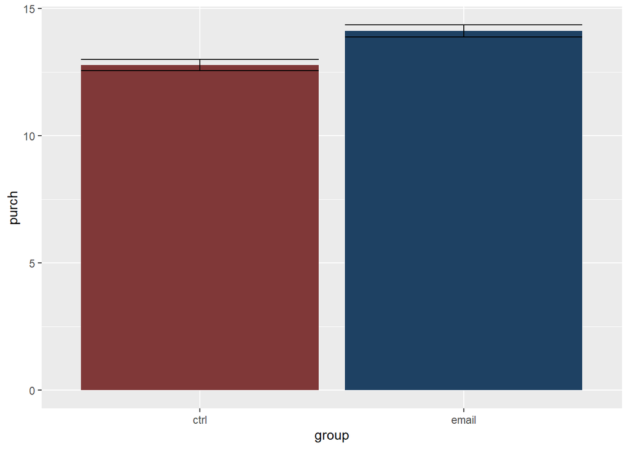

```r
dodge = position_dodge(width=1); ##to form constant dimensions
ggplot(aes(x=group,y=purch,ymax=purch+sePurch,ymin=purch-sePurch),data=dagg)+
  geom_bar(position=dodge,stat="identity", fill =c("#803838", "#1E4163"))  +
  geom_errorbar(position=dodge)
```

```r
  labs(x="Group",y="Purchases")
```

```
## $x
## [1] "Group"
##
## $y
## [1] "Purchases"
##
## attr(,"class")
## [1] "labels"
```

```r
# Get the average causal effect without control variables
summary(lm(purch~group,data=wine))
```

```
##
## Call:
## lm(formula = purch ~ group, data = wine)
##
## Residuals:
##     Min      1Q  Median      3Q     Max
##  -14.12  -14.12  -12.77  -12.77 1798.38
##
## Coefficients:
##             Estimate Std. Error t value Pr(>|t|)
## (Intercept)  12.7727     0.2260  56.528  < 2e-16 ***
## groupemail    1.3465     0.3195   4.214 2.52e-05 ***
## ---
## Signif. codes:  0 '***' 0.001 '**' 0.01 '*' 0.05 '.' 0.1 ' ' 1
##
## Residual standard error: 44.71 on 78310 degrees of freedom
## Multiple R-squared:  0.0002267,  Adjusted R-squared:  0.0002139
## F-statistic: 17.76 on 1 and 78310 DF,  p-value: 2.515e-05
```

```r
wine$email = (wine$group != "ctrl")

summary(lm(purch~email,data=wine))
```

```
##
## Call:
## lm(formula = purch ~ email, data = wine)
##
## Residuals:
##     Min      1Q  Median      3Q     Max
##  -14.12  -14.12  -12.77  -12.77 1798.38
##
## Coefficients:
##             Estimate Std. Error t value Pr(>|t|)
## (Intercept)  12.7727     0.2260  56.528  < 2e-16 ***
## emailTRUE     1.3465     0.3195   4.214 2.52e-05 ***
## ---
## Signif. codes:  0 '***' 0.001 '**' 0.01 '*' 0.05 '.' 0.1 ' ' 1
##
## Residual standard error: 44.71 on 78310 degrees of freedom
## Multiple R-squared:  0.0002267,  Adjusted R-squared:  0.0002139
## F-statistic: 17.76 on 1 and 78310 DF,  p-value: 2.515e-05
```

```r
# Add control variables since there may be some contamination
summary(lm(purch~email+chard+sav_blanc+syrah+cab+past_purch+last_purch+visits,data=wine))
```

```
##
## Call:
## lm(formula = purch ~ email + chard + sav_blanc + syrah + cab +
##     past_purch + last_purch + visits, data = wine)
##
## Residuals:
##     Min      1Q  Median      3Q     Max
## -420.37  -14.57  -10.31   -1.72 1798.77
##
## Coefficients: (1 not defined because of singularities)
##               Estimate Std. Error t value Pr(>|t|)
## (Intercept) 14.5269957  0.4363336  33.293  < 2e-16 ***
## emailTRUE    1.2603997  0.3101382   4.064 4.83e-05 ***
## chard        0.0346117  0.0007959  43.489  < 2e-16 ***
## sav_blanc    0.0433309  0.0020630  21.004  < 2e-16 ***
## syrah        0.0240070  0.0149648   1.604    0.109
## cab          0.0489413  0.0020948  23.363  < 2e-16 ***
## past_purch          NA         NA      NA       NA
## last_purch  -0.0718125  0.0017235 -41.667  < 2e-16 ***
## visits      -0.0627548  0.0655217  -0.958    0.338
## ---
## Signif. codes:  0 '***' 0.001 '**' 0.01 '*' 0.05 '.' 0.1 ' ' 1
##
## Residual standard error: 43.39 on 78304 degrees of freedom
## Multiple R-squared:  0.05836,    Adjusted R-squared:  0.05827
## F-statistic: 693.3 on 7 and 78304 DF,  p-value: < 2.2e-16
```

```r
# Rule out the 'past purchase' because of colinearity
summary(lm(purch~group+chard+sav_blanc+syrah+cab+last_purch+visits,data=wine))
```

```
##
## Call:
## lm(formula = purch ~ group + chard + sav_blanc + syrah + cab +
##     last_purch + visits, data = wine)
##
## Residuals:
##     Min      1Q  Median      3Q     Max
## -420.37  -14.57  -10.31   -1.72 1798.77
##
## Coefficients:
##               Estimate Std. Error t value Pr(>|t|)
## (Intercept) 14.5269957  0.4363336  33.293  < 2e-16 ***
## groupemail   1.2603997  0.3101382   4.064 4.83e-05 ***
## chard        0.0346117  0.0007959  43.489  < 2e-16 ***
## sav_blanc    0.0433309  0.0020630  21.004  < 2e-16 ***
## syrah        0.0240070  0.0149648   1.604    0.109
## cab          0.0489413  0.0020948  23.363  < 2e-16 ***
## last_purch  -0.0718125  0.0017235 -41.667  < 2e-16 ***
## visits      -0.0627548  0.0655217  -0.958    0.338
## ---
## Signif. codes:  0 '***' 0.001 '**' 0.01 '*' 0.05 '.' 0.1 ' ' 1
##
## Residual standard error: 43.39 on 78304 degrees of freedom
## Multiple R-squared:  0.05836,    Adjusted R-squared:  0.05827
## F-statistic: 693.3 on 7 and 78304 DF,  p-value: < 2.2e-16
```

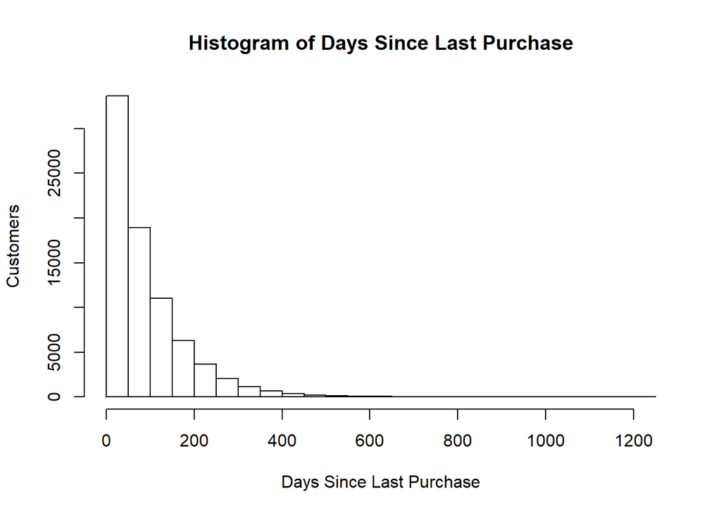

```r
# Plot the histogram for most recent purchase
hist(wine$last_purch,
     xlab="Days Since Last Purchase", ylab="Customers",
     main="Histogram of Days Since Last Purchase")
```

```r
# Find the time period for recency
wine$recentPurch = (wine$last_purch < 45)
```

b)Slice and dice analysis: For this section, we illustrated the potential for targeting on response for this email with various causal effects which make differences. And plot each slice and dice analysis results.

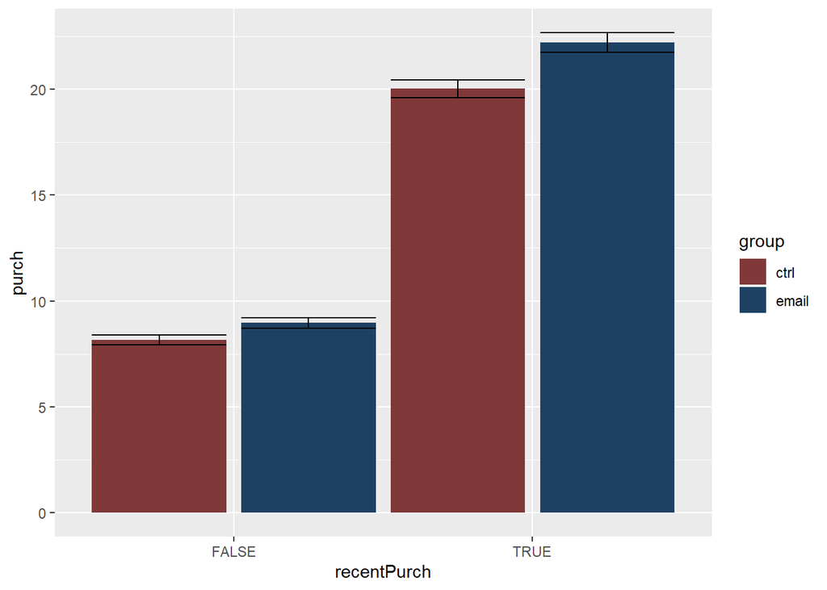

```r
# Slice and dice analysis for test groups
# Rencency

dt = data.table(wine)
dagg = dt[,.(open = mean(open), click=mean(click), purch = mean(purch),seOpen = sd(open)/sqrt(.N), seClick=sd(click)/sqrt(.N), sePurch = sd(purch)/sqrt(.N),.N),by = .(group,recentPurch)]

dodge = position_dodge(width=1);
ggplot(aes(fill=group,y=purch,x=recentPurch,ymax=purch+sePurch,ymin=purch-sePurch),data=dagg)+
  geom_bar(position=dodge,stat="identity") + scale_fill_manual(values=c("#803838", "#1E4163")) +
  geom_errorbar(position=dodge)
```

```r
  labs(x="Group",y="Purchases")
```

```
## $x
## [1] "Group"
##
## $y
## [1] "Purchases"
##
## attr(,"class")
## [1] "labels"
```

```r
# Slice and dice analysis for test groups
# buySyrah but may not useful since based on the coefficients, Syrah is not significant.

wine$buySyrah <- (wine$syrah > 0) # >0 to show whether bought this product
dt = data.table(wine)
dagg = dt[,.(open = mean(open), click=mean(click), purch = mean(purch),seOpen = sd(open)/sqrt(.N), seClick=sd(click)/sqrt(.N), sePurch = sd(purch)/sqrt(.N),.N),by = .(group,buySyrah)]
dagg
```

```
##    group buySyrah      open     click    purch      seOpen     seClick
## 1: email    FALSE 0.7904842 0.1333546 14.15292 0.002190032 0.001829448
## 2:  ctrl    FALSE 0.0000000 0.0000000 12.68421 0.000000000 0.000000000
## 3: email     TRUE 0.8354239 0.1438149 13.86684 0.005453495 0.005160880
## 4:  ctrl     TRUE 0.0000000 0.0000000 13.45202 0.000000000 0.000000000
##      sePurch     N
## 1: 0.2498550 34532
## 2: 0.2308566 34645
## 3: 0.6430488  4624
## 4: 0.6762001  4511
```

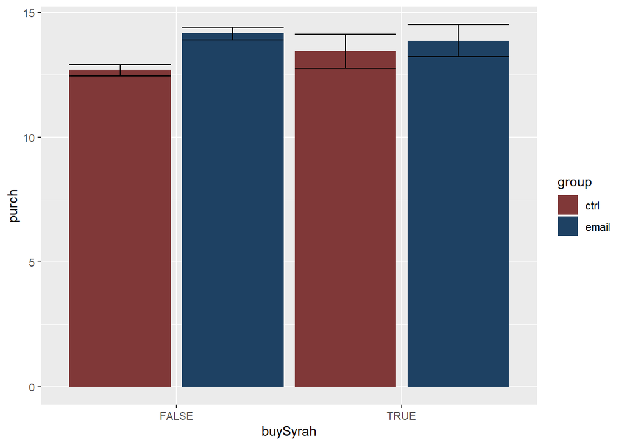

```r
#Plot the results
dodge = position_dodge(width=1);
ggplot(aes(fill=group,y=purch,x=buySyrah,ymax=purch+sePurch,ymin=purch-sePurch),data=dagg)+
  geom_bar(position=dodge,stat="identity") + scale_fill_manual(values=c("#803838", "#1E4163")) +
  geom_errorbar(position=dodge)
```

```r
  labs(x="Group",y="Purchases")
```

```
## $x
## [1] "Group"
##
## $y
## [1] "Purchases"
##
## attr(,"class")
## [1] "labels"
```

```r
# Slice and dice analysis for test groups
# buyChard

wine$buyChard <- (wine$chard > 0) # >0 to show whether bought this product
dt = data.table(wine)
dagg = dt[,.(open = mean(open), click=mean(click), purch = mean(purch),seOpen = sd(open)/sqrt(.N), seClick=sd(click)/sqrt(.N), sePurch = sd(purch)/sqrt(.N),.N),by = .(group,buyChard)]
dagg
```

```
##    group buyChard      open     click     purch      seOpen     seClick
## 1: email    FALSE 0.7349885 0.1273105 10.832613 0.002664867 0.002012635
## 2:  ctrl    FALSE 0.0000000 0.0000000  9.668629 0.000000000 0.000000000
## 3: email     TRUE 0.9380063 0.1516159 21.806176 0.002226905 0.003312026
## 4:  ctrl     TRUE 0.0000000 0.0000000 20.119320 0.000000000 0.000000000
##      sePurch     N
## 1: 0.2512667 27429
## 2: 0.2297507 27526
## 3: 0.5030103 11727
## 4: 0.4893439 11630
```

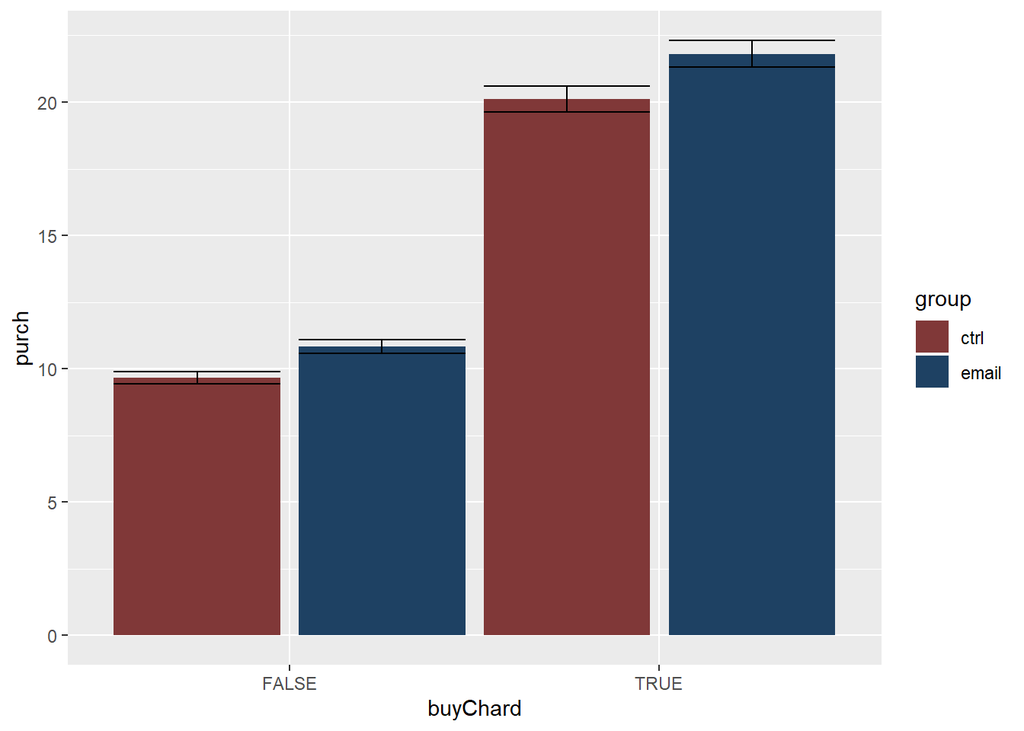

```r
#Plot the results
dodge = position_dodge(width=1);
ggplot(aes(fill=group,y=purch,x=buyChard,ymax=purch+sePurch,ymin=purch-sePurch),data=dagg)+
  geom_bar(position=dodge,stat="identity") + scale_fill_manual(values=c("#803838", "#1E4163")) +
  geom_errorbar(position=dodge)
```

```r
  labs(x="Group",y="Purchases")
```

```
## $x
## [1] "Group"
##
## $y
## [1] "Purchases"
##
## attr(,"class")
## [1] "labels"
```

```r
# Slice and dice analysis for test groups
# buySav_blanc

wine$buySav_blanc  <- (wine$sav_blanc > 0)
dt = data.table(wine)
dagg = dt[,.(open = mean(open), click=mean(click), purch = mean(purch),seOpen = sd(open)/sqrt(.N), seClick=sd(click)/sqrt(.N), sePurch = sd(purch)/sqrt(.N),.N),by = .(group,buySav_blanc )]
dagg
```

```
##    group buySav_blanc      open     click    purch      seOpen     seClick
## 1: email        FALSE 0.7584662 0.1060742 12.73262 0.002562264 0.001843412
## 2:  ctrl        FALSE 0.0000000 0.0000000 11.97850 0.000000000 0.000000000
## 3:  ctrl         TRUE 0.0000000 0.0000000 14.75347 0.000000000 0.000000000
## 4: email         TRUE 0.8883655 0.2053151 17.55800 0.002969059 0.003808304
##      sePurch     N
## 1: 0.2595973 27905
## 2: 0.2536487 27950
## 3: 0.4275318 11206
## 4: 0.4918374 11251
```

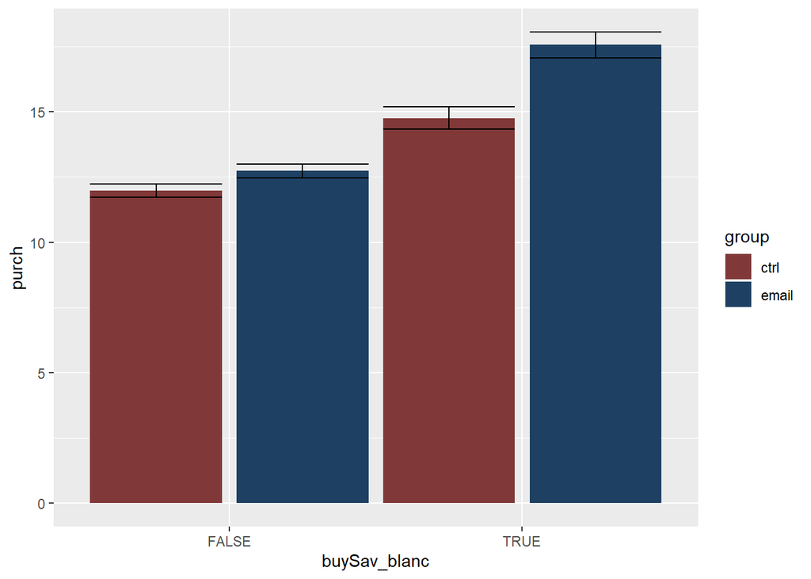

```r
#Plot the results
dodge = position_dodge(width=1);
ggplot(aes(fill=group,y=purch,x=buySav_blanc ,ymax=purch+sePurch,ymin=purch-sePurch),data=dagg)+
  geom_bar(position=dodge,stat="identity") +  scale_fill_manual(values=c("#803838", "#1E4163")) +
  geom_errorbar(position=dodge)
```

```r
  labs(x="Group",y="Purchases")
```

```
## $x
## [1] "Group"
##
## $y
## [1] "Purchases"
##
## attr(,"class")
## [1] "labels"
```

```r
# Slice and dice analysis for test groups
# buyCab

wine$buyCab  <- (wine$cab > 0) # or > 0
dt = data.table(wine)
dagg = dt[,.(open = mean(open), click=mean(click), purch = mean(purch),seOpen = sd(open)/sqrt(.N), seClick=sd(click)/sqrt(.N), sePurch = sd(purch)/sqrt(.N),.N),by = .(group,buyCab )]
dagg
```

```
##    group buyCab      open     click    purch      seOpen     seClick
## 1: email  FALSE 0.7591097 0.1113983 12.78465 0.002562230 0.001885164
## 2:  ctrl   TRUE 0.0000000 0.0000000 15.46013 0.000000000 0.000000000
## 3: email   TRUE 0.8862048 0.1917529 17.40840 0.002987376 0.003703428
## 4:  ctrl  FALSE 0.0000000 0.0000000 11.69814 0.000000000 0.000000000
##      sePurch     N
## 1: 0.2691113 27855
## 2: 0.4519108 11184
## 3: 0.4591229 11301
## 4: 0.2466952 27972
```

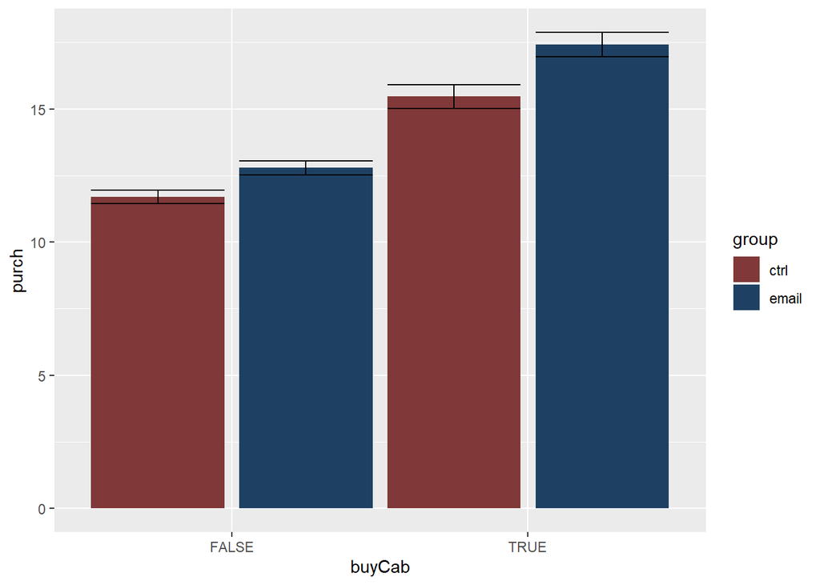

```r
#Plot the results
dodge = position_dodge(width=1);
ggplot(aes(fill=group,y=purch,x=buyCab ,ymax=purch+sePurch,ymin=purch-sePurch),data=dagg)+
  geom_bar(position=dodge,stat="identity") + scale_fill_manual(values=c("#803838", "#1E4163")) +
  geom_errorbar(position=dodge)
```

```r
  labs(x="Group",y="Purchases")
```

```
## $x
## [1] "Group"
##
## $y
## [1] "Purchases"
##
## attr(,"class")
## [1] "labels"
```

```r
# Try different products' causal effect on purchasing

summary(lm(purch~email*recentPurch,data=wine))
```

```
##
## Call:
## lm(formula = purch ~ email * recentPurch, data = wine)
##
## Residuals:
##     Min      1Q  Median      3Q     Max
##  -22.20  -20.01   -8.96   -8.16 1803.54
##
## Coefficients:
##                           Estimate Std. Error t value Pr(>|t|)
## (Intercept)                 8.1578     0.2865  28.479   <2e-16 ***
## emailTRUE                   0.8001     0.4052   1.975   0.0483 *
## recentPurchTRUE            11.8491     0.4590  25.815   <2e-16 ***
## emailTRUE:recentPurchTRUE   1.3932     0.6491   2.146   0.0318 *
## ---
## Signif. codes:  0 '***' 0.001 '**' 0.01 '*' 0.05 '.' 0.1 ' ' 1
##
## Residual standard error: 44.29 on 78308 degrees of freedom
## Multiple R-squared:  0.019,  Adjusted R-squared:  0.01897
## F-statistic: 505.7 on 3 and 78308 DF,  p-value: < 2.2e-16
```

```r
summary(lm(purch~recentPurch + email:recentPurch,data=wine))
```

```
##
## Call:
## lm(formula = purch ~ recentPurch + email:recentPurch, data = wine)
##
## Residuals:
##     Min      1Q  Median      3Q     Max
##  -22.20  -20.01   -8.96   -8.16 1803.54
##
## Coefficients:
##                            Estimate Std. Error t value Pr(>|t|)
## (Intercept)                  8.1578     0.2865  28.479  < 2e-16 ***
## recentPurchTRUE             11.8491     0.4590  25.815  < 2e-16 ***
## recentPurchFALSE:emailTRUE   0.8001     0.4052   1.975   0.0483 *
## recentPurchTRUE:emailTRUE    2.1934     0.5071   4.325 1.53e-05 ***
## ---
## Signif. codes:  0 '***' 0.001 '**' 0.01 '*' 0.05 '.' 0.1 ' ' 1
##
## Residual standard error: 44.29 on 78308 degrees of freedom
## Multiple R-squared:  0.019,  Adjusted R-squared:  0.01897
## F-statistic: 505.7 on 3 and 78308 DF,  p-value: < 2.2e-16
```

```r
summary(lm(purch~buyCab + buyCab:group,data=wine))
```

```
##
## Call:
## lm(formula = purch ~ buyCab + buyCab:group, data = wine)
##
## Residuals:
##     Min      1Q  Median      3Q     Max
##  -17.41  -12.78  -11.70  -11.70 1799.72
##
## Coefficients:
##                        Estimate Std. Error t value Pr(>|t|)
## (Intercept)             11.6981     0.2671  43.797  < 2e-16 ***
## buyCabTRUE               3.7620     0.4998   7.527 5.23e-14 ***
## buyCabFALSE:groupemail   1.0865     0.3781   2.873  0.00406 **
## buyCabTRUE:groupemail    1.9483     0.5958   3.270  0.00108 **
## ---
## Signif. codes:  0 '***' 0.001 '**' 0.01 '*' 0.05 '.' 0.1 ' ' 1
##
## Residual standard error: 44.67 on 78308 degrees of freedom
## Multiple R-squared:  0.002046,   Adjusted R-squared:  0.002008
## F-statistic: 53.53 on 3 and 78308 DF,  p-value: < 2.2e-16
```

```r
summary(lm(purch~buySav_blanc + buySav_blanc:group,data=wine))
```

```
##
## Call:
## lm(formula = purch ~ buySav_blanc + buySav_blanc:group, data = wine)
##
## Residuals:
##     Min      1Q  Median      3Q     Max
##  -17.56  -12.73  -11.98  -11.98 1794.94
##
## Coefficients:
##                              Estimate Std. Error t value Pr(>|t|)
## (Intercept)                   11.9785     0.2672  44.824  < 2e-16 ***
## buySav_blancTRUE               2.7750     0.4995   5.555 2.78e-08 ***
## buySav_blancFALSE:groupemail   0.7541     0.3781   1.995   0.0461 *
## buySav_blancTRUE:groupemail    2.8045     0.5963   4.704 2.56e-06 ***
## ---
## Signif. codes:  0 '***' 0.001 '**' 0.01 '*' 0.05 '.' 0.1 ' ' 1
##
## Residual standard error: 44.68 on 78308 degrees of freedom
## Multiple R-squared:  0.001812,   Adjusted R-squared:  0.001774
## F-statistic: 47.39 on 3 and 78308 DF,  p-value: < 2.2e-16
```

```r
summary(lm(purch~buyChard + buyChard:group,data=wine))
```

```
##
## Call:
## lm(formula = purch ~ buyChard + buyChard:group, data = wine)
##
## Residuals:
##     Min      1Q  Median      3Q     Max
##  -21.81  -10.83   -9.67   -9.67 1801.67
##
## Coefficients:
##                          Estimate Std. Error t value Pr(>|t|)
## (Intercept)                9.6686     0.2679   36.09  < 2e-16 ***
## buyChardTRUE              10.4507     0.4915   21.26  < 2e-16 ***
## buyChardFALSE:groupemail   1.1640     0.3792    3.07  0.00214 **
## buyChardTRUE:groupemail    1.6869     0.5816    2.90  0.00373 **
## ---
## Signif. codes:  0 '***' 0.001 '**' 0.01 '*' 0.05 '.' 0.1 ' ' 1
##
## Residual standard error: 44.44 on 78308 degrees of freedom
## Multiple R-squared:  0.01225,    Adjusted R-squared:  0.01221
## F-statistic: 323.6 on 3 and 78308 DF,  p-value: < 2.2e-16
```

c)“Individual-level” conditional causal effect: For this section, we use causal forest to further validate our results of previous model. Causal forest was applied in this part. The blackbox model of causal forest would give us results and importance of different variables automatically with machine learning. And we also predict the training data based on the model, as well as estimate the average treatment effect for the target sample.

```r
#Causal forest

set.seed(0) # To produce identical results
treat <- wine$email
response <- wine$purch
baseline <- wine[, c("last_purch", "visits", "chard", "sav_blanc", "syrah", "cab")]
tmp=proc.time()[3]
cf <- causal_forest(baseline, response, treat)
tmp = proc.time()[3]-tmp
print(cf)
```

```
## GRF forest object of type causal_forest
## Number of trees: 2000
## Number of training samples: 78312
## Variable importance:
##     1     2     3     4     5     6
## 0.226 0.043 0.296 0.247 0.053 0.135
```

```r
#Find the average treatment effect of causal forest
average_treatment_effect(cf, method="AIPW")
```

```
##  estimate   std.err
## 1.3176681 0.3098432
```

Taking the margin and cost into account, we also estimate who should be sent email.

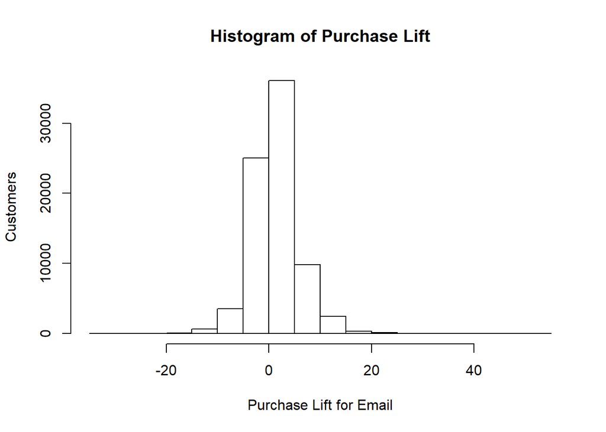

```r
#Create a file for prediction
predict_form <- predict(cf)

#Plot the overall purchase lift for
hist(predict(cf)$predictions,
     main="Histogram of Purchase Lift",
     xlab="Purchase Lift for Email", ylab="Customers")
```

```r
#Calculate the margin and decide whether to send emails
predict_form$margin <- predict_form$predictions * 0.3 - 0.1
predict_form$sent <- predict_form$margin > 0

#Find the average causal effect based on the people who should be sent emails
dt_wine = data.table(wine[predict_form$sent,])
dagg = dt_wine[,.(open = mean(open), click=mean(click), purch = mean(purch),seOpen = sd(open)/sqrt(.N), seClick=sd(click)/sqrt(.N), sePurch = sd(purch)/sqrt(.N),.N),by = .(group)]
```

And we assign the score for the training data and show the characteristics of the target group and non-target group.

```r
#Assign score based on the margin and cost
wine[,c('prediction','debiased.error', 'excess.error', 'score','sent')]<- predict_form[,1:5]


#Give a general view of the target and non-target group
summary(wine[predict_form$sent,c('purch','chard','sav_blanc','syrah','cab','past_purch','last_purch','visits')])
```

```
##      purch             chard            sav_blanc           syrah
##  Min.   :   0.00   Min.   :    0.00   Min.   :   0.00   Min.   :  0.000
##  1st Qu.:   0.00   1st Qu.:    0.00   1st Qu.:   0.00   1st Qu.:  0.000
##  Median :   0.00   Median :    0.00   Median :   0.00   Median :  0.000
##  Mean   :  15.86   Mean   :   94.39   Mean   :  28.55   Mean   :  2.326
##  3rd Qu.:   5.92   3rd Qu.:   78.17   3rd Qu.:  34.06   3rd Qu.:  0.000
##  Max.   :1812.50   Max.   :13379.44   Max.   :3843.24   Max.   :261.560
##       cab            past_purch         last_purch          visits
##  Min.   :   0.00   Min.   :    0.00   Min.   :   0.00   Min.   : 0.000
##  1st Qu.:   0.00   1st Qu.:    0.00   1st Qu.:  22.00   1st Qu.: 4.000
##  Median :   0.00   Median :   67.93   Median :  53.00   Median : 5.000
##  Mean   :  30.45   Mean   :  155.71   Mean   :  72.58   Mean   : 5.673
##  3rd Qu.:  30.04   3rd Qu.:  202.89   3rd Qu.: 101.00   3rd Qu.: 7.000
##  Max.   :1826.31   Max.   :13379.44   Max.   :1054.00   Max.   :64.000
```

```r
summary(wine[!predict_form$sent,c('purch','chard','sav_blanc','syrah','cab','past_purch','last_purch','visits')])
```

```
##      purch             chard           sav_blanc           syrah
##  Min.   :   0.00   Min.   :   0.00   Min.   :   0.00   Min.   :  0.000
##  1st Qu.:   0.00   1st Qu.:   0.00   1st Qu.:   0.00   1st Qu.:  0.000
##  Median :   0.00   Median :   0.00   Median :   0.00   Median :  0.000
##  Mean   :  10.39   Mean   :  48.17   Mean   :  24.39   Mean   :  3.493
##  3rd Qu.:   0.00   3rd Qu.:  29.40   3rd Qu.:   0.00   3rd Qu.:  0.000
##  Max.   :1231.10   Max.   :4903.31   Max.   :2561.03   Max.   :360.320
##       cab            past_purch        last_purch         visits
##  Min.   :   0.00   Min.   :   0.00   Min.   :   0.0   Min.   : 0.000
##  1st Qu.:   0.00   1st Qu.:   0.00   1st Qu.:  36.0   1st Qu.: 4.000
##  Median :   0.00   Median :  36.79   Median :  81.0   Median : 5.000
##  Mean   :  22.69   Mean   :  98.74   Mean   : 112.2   Mean   : 5.614
##  3rd Qu.:   0.00   3rd Qu.: 132.43   3rd Qu.: 166.0   3rd Qu.: 7.000
##  Max.   :2649.78   Max.   :5353.42   Max.   :1225.0   Max.   :31.000
```

```r
#Find the colmeans of each variables for target group and non-target group
char_target <- colMeans(wine[predict_form$sent,c('purch','chard','sav_blanc','syrah','cab','past_purch','last_purch','visits','recentPurch')])
char_non_target <- colMeans(wine[!predict_form$sent,c('purch','chard','sav_blanc','syrah','cab','past_purch','last_purch','visits','recentPurch')])
```

```r
#Calculate the proortion of target consumers based on the whole training data
nrow(wine[predict_form$sent,])/nrow(wine)*100
```

```
## [1] 55.91608
```

```r
newdata <- wine[,c(1,23,24)]
write.csv(newdata,file = 'newdata.csv')
```